# Homework 1

## Compare these rates with the national average for the same year and report the results.

We want to compare province participation rates with the national average to identify variations above and below the average.

**Calculation of National Average:**

- The national average participation rate is computed using `calculate_participation_rate` function.

```r
# Calculate the national average participation rate for the specified year
national_average <- calculate_participation_rate(LFS97_above_15$Employment, LFS97_above_15$Weight)
cat("National average for participation rate is:", national_average)
```

```
## National average for participation rate is: 0.4451241
```

**Comparison with National Average:**

- Provincial participation rates are compared to the national average. Provinces with rates higher than the average are labeled “Above Average”, while those with lower rates are labeled “Below Average”.

```r
# Compare participation rates with the national average
top_bottom_three_97 <- top_bottom_three_97 %>%
  mutate(compare_to_average = ifelse(participation_rate > national_average, "Above Average", "Below Average"))


# Report the results
knitr::kable(top_bottom_three_97, align = "lcc", caption = "Comparison of Participation Rates with National Average")
```

Comparison of Participation Rates with National Average

| province | participation_rate | compare_to_average |
| --- | --- | --- |
| North Khorasan | 0.5016697 | Above Average |
| Ardabil | 0.4850434 | Above Average |
| Razavi Khorasan | 0.4786794 | Above Average |
| Ilam | 0.3959690 | Below Average |
| Qom | 0.3901674 | Below Average |
| Markazi | 0.3790706 | Below Average |

## Visualize the participation rates for these provinces and the whole country from 1397 to 1401.

### **Function to Filter Individuals Above the Age of 15**:

- We define function`filter_above_15` to filter individuals above the age of 15 from each dataset and create a new dataframe.

```r
# Function to filter individuals above the age of 15 from each dataset and create a new dataframe
filter_above_15 <- function(dataset) {
  above_15 <- dataset[dataset$Age >= 15, ]
  return(above_15)
}
```

### Function to Extract Province Information:

- We define function `add_province_column` to extract province information from the ‘Address’ column and add it as a new column to each dataset.

```r
# Function to extract province information from the 'Address' column and add it as a new column to each dataset
add_province_column <- function(dataset) {
  dataset$province <- substr(dataset$Address, start = 3, stop = 4)
  return(dataset)
}
```

### Apply Functions to Each Dataset:

Apply the filtering and province extraction functions to each year’s dataset.

```r
# Apply filter_above_15 function to each dataset
filtered_datasets <- lapply(list(LFS97, LFS98, LFS99, LFS400, LFS401), filter_above_15)

# Apply add_province_column function to each filtered dataset
datasets_with_province <- lapply(filtered_datasets, add_province_column)

# Access the datasets with province information
LFS1397_above15_province <- datasets_with_province[[1]]
LFS1398_above15_province <- datasets_with_province[[2]]
LFS1399_above15_province <- datasets_with_province[[3]]
LFS1400_above15_province <- datasets_with_province[[4]]
LFS1401_above15_province <- datasets_with_province[[5]]
```

### Remove Useless Datasets:

In this part, we will remove datasets which are no longer needed.

```r
# Remove useless datasets
rm(LFS97, LFS97_above_15, LFS98, LFS99, LFS400, LFS401, datasets_with_province, filtered_datasets)
```

### Function Definition to Calculate Participation Rates:

- Function `calculate_participation_rates` iterates over each year from 1397 to 1401 and calculates the participation rates for both the whole country and individual provinces.
- It stores the results in a dataframe `participation_data` and returns it.

```r
# Function to calculate participation rates for each year and province
calculate_participation_rates <- function(dataset) {
  # Create an empty dataframe to store the results
  participation_data <- data.frame(Year = numeric(), Province = character(), Participation_Rate = numeric())

  # Extract year from dataset name
  dataset_name <- deparse(substitute(dataset))
  year <- as.numeric(str_extract(string = dataset_name, pattern = "(?<=LFS)\\d+"))

  # Calculate participation rates for the whole country
  country_participation_rate <- calculate_participation_rate(dataset$Employment, dataset$Weight)

  # Store participation rate for the whole country
  participation_data <- rbind(participation_data, data.frame(Year = year, Province = "Country", Participation_Rate = country_participation_rate))

  # Calculate participation rates for provinces
  province_participation_rates <- aggregate(Employment ~ province, data = dataset, FUN = function(x) calculate_participation_rate(x, dataset$Weight))

  # Store participation rates for provinces
  participation_data <- rbind(participation_data, data.frame(Year = rep(year, nrow(province_participation_rates)), Province = province_participation_rates$province, Participation_Rate = province_participation_rates$Employment))

  return(participation_data)
}
```

### Calculate Participation Rates for Each Dataset:

In this part, we calculate participation rates for each dataset(LFS97, LFS98, LFS99, LFS400, LFS401) by calling the `calculate_participation_rates` function with the respective datasets.

```r
# Calculate participation rates for each dataset
participation_rates_LFS1397 <- calculate_participation_rates(LFS1397_above15_province)
participation_rates_LFS1398 <- calculate_participation_rates(LFS1398_above15_province)
participation_rates_LFS1399 <- calculate_participation_rates(LFS1399_above15_province)
participation_rates_LFS1400 <- calculate_participation_rates(LFS1400_above15_province)
participation_rates_LFS1401 <- calculate_participation_rates(LFS1401_above15_province)
```

### Visualization of Participation Rates:

#### **Data Manipulation**:

- The following block renames the participation rate columns in each dataframe to match specific names of each year.
- Then we merge the participation columns from multiple dataframes based on provinces, resulting in a single dataframe containing participation rates for different years and provinces.
- The participation rates are multiplied by 100 and rounded to one decimal place.

```r
# Rename participation rate columns in each dataframe
names(participation_rates_LFS1397)[names(participation_rates_LFS1397) == "Participation_Rate"] <- "Participation_LFS1397"
names(participation_rates_LFS1398)[names(participation_rates_LFS1398) == "Participation_Rate"] <- "Participation_LFS1398"
names(participation_rates_LFS1399)[names(participation_rates_LFS1399) == "Participation_Rate"] <- "Participation_LFS1399"
names(participation_rates_LFS1400)[names(participation_rates_LFS1400) == "Participation_Rate"] <- "Participation_LFS1400"
names(participation_rates_LFS1401)[names(participation_rates_LFS1401) == "Participation_Rate"] <- "Participation_LFS1401"

# Merge participation columns from old dataframes based on provinces
merged_participation <- merge(merge(merge(merge(participation_rates_LFS1397[, -1], participation_rates_LFS1398[, -1], by = "Province", all = TRUE), participation_rates_LFS1399[, -1], by = "Province", all = TRUE), participation_rates_LFS1400[, -1], by = "Province", all = TRUE), participation_rates_LFS1401[, -1], by = "Province", all = TRUE)

# Multiply each participation rate by 100 and round it to one decimal place
merged_participation[, -1] <- round(merged_participation[, -1] * 100, 1)

# Print the merged dataframe
knitr::kable(merged_participation, align = "lccccc", caption = "Participation Rates Over Time (By Province Codes)", row.names = FALSE)
```

Participation Rates Over Time (By Province Codes)

| Province | Participation_LFS1397 | Participation_LFS1398 | Participation_LFS1399 | Participation_LFS1400 | Participation_LFS1401 |
| --- | --- | --- | --- | --- | --- |
| 00 | 36.7 | 36.4 | 34.9 | 35.3 | 35.2 |
| 01 | 47.0 | 46.4 | 43.8 | 44.0 | 43.3 |
| 02 | 44.3 | 45.8 | 42.9 | 42.2 | 43.2 |
| 03 | 44.5 | 44.4 | 42.7 | 41.6 | 40.2 |
| 04 | 47.3 | 46.2 | 43.1 | 43.0 | 42.9 |
| 05 | 48.0 | 48.4 | 44.6 | 42.7 | 41.2 |
| 06 | 44.1 | 43.6 | 40.1 | 39.2 | 39.7 |
| 07 | 43.7 | 41.6 | 37.2 | 36.3 | 35.7 |
| 08 | 43.1 | 41.3 | 38.9 | 39.0 | 37.7 |
| 09 | 48.1 | 46.4 | 42.7 | 40.2 | 42.5 |
| 10 | 46.7 | 44.7 | 40.7 | 39.9 | 40.1 |
| 11 | 39.9 | 37.4 | 33.6 | 33.8 | 33.3 |
| 12 | 47.8 | 47.0 | 43.8 | 41.9 | 42.5 |
| 13 | 45.8 | 46.7 | 42.5 | 41.1 | 43.1 |
| 14 | 45.0 | 44.1 | 41.8 | 39.7 | 39.6 |
| 15 | 40.2 | 40.2 | 40.6 | 40.5 | 40.3 |
| 16 | 40.4 | 38.7 | 35.2 | 34.7 | 33.4 |
| 17 | 41.1 | 39.9 | 34.8 | 33.4 | 32.8 |
| 18 | 43.3 | 41.0 | 37.8 | 37.5 | 38.6 |
| 19 | 47.5 | 50.7 | 46.1 | 45.9 | 49.2 |
| 20 | 39.6 | 38.6 | 36.4 | 35.9 | 36.0 |
| 21 | 46.3 | 45.8 | 44.8 | 46.0 | 44.4 |
| 22 | 41.6 | 46.0 | 47.3 | 44.0 | 41.1 |
| 23 | 42.5 | 42.1 | 39.3 | 40.5 | 39.7 |
| 24 | 50.7 | 49.1 | 47.5 | 47.0 | 47.3 |
| 25 | 38.4 | 39.2 | 37.4 | 36.3 | 36.0 |
| 26 | 45.9 | 45.6 | 43.3 | 44.3 | 44.2 |
| 27 | 42.0 | 40.7 | 37.8 | 36.6 | 36.1 |
| 28 | 50.0 | 47.8 | 45.0 | 44.1 | 41.8 |
| 29 | 45.6 | 45.4 | 41.6 | 41.6 | 40.2 |
| 30 | 41.7 | 43.1 | 39.7 | 38.7 | 38.0 |
| Country | 44.5 | 44.1 | 41.3 | 40.9 | 40.9 |

#### **Data Filtering:**

```r
# Filter and keep only the provinces 00, 25, 16, 09, 24, and 28
filtered_merged_participation <- subset(merged_participation, Province %in% c("00", "25", "16", "09", "24", "28", "Country"))

# Replace province codes with names in the filtered dataframe
filtered_merged_participation$Province <- province_dict[filtered_merged_participation$Province]

# Print the filtered dataframe
knitr::kable(filtered_merged_participation, align = "lccccc", caption = "Participation rates over time for selected provinces", row.names = FALSE)
```

Participation rates over time for selected provinces

| Province | Participation_LFS1397 | Participation_LFS1398 | Participation_LFS1399 | Participation_LFS1400 | Participation_LFS1401 |
| --- | --- | --- | --- | --- | --- |
| Markazi | 36.7 | 36.4 | 34.9 | 35.3 | 35.2 |
| Razavi Khorasan | 48.1 | 46.4 | 42.7 | 40.2 | 42.5 |
| Ilam | 40.4 | 38.7 | 35.2 | 34.7 | 33.4 |
| Ardabil | 50.7 | 49.1 | 47.5 | 47.0 | 47.3 |
| Qom | 38.4 | 39.2 | 37.4 | 36.3 | 36.0 |
| North Khorasan | 50.0 | 47.8 | 45.0 | 44.1 | 41.8 |
| Iran | 44.5 | 44.1 | 41.3 | 40.9 | 40.9 |

#### **Table manipulation:**

**Converting Data Types:** - Converts certain columns to numeric data type for analysis.

```r
# Convert province column to character
filtered_merged_participation$Province <- as.character(filtered_merged_participation$Province)

# Convert participation rate column to numeric
filtered_merged_participation$Participation_LFS1397 <- as.numeric(filtered_merged_participation$Participation_LFS1397)
filtered_merged_participation$Participation_LFS1398 <- as.numeric(filtered_merged_participation$Participation_LFS1398)
filtered_merged_participation$Participation_LFS1399 <- as.numeric(filtered_merged_participation$Participation_LFS1399)
filtered_merged_participation$Participation_LFS1400 <- as.numeric(filtered_merged_participation$Participation_LFS1400)
filtered_merged_participation$Participation_LFS1401 <- as.numeric(filtered_merged_participation$Participation_LFS1401)
```

**Shortening Column Names:** - Removes prefix “Participation_LFS” from column names. - Retains only year numbers.

```r
# Shorten column names
shortened_column_names <- gsub("Participation_LFS(\\d+)", "\\1", names(filtered_merged_participation)[-1])

# Rename the first column
names(filtered_merged_participation)[1] <- "Province"

# Create a data frame with shortened column names
shortened_data <- cbind(filtered_merged_participation[, 1, drop = FALSE], filtered_merged_participation[, -1])
names(shortened_data)[-1] <- shortened_column_names

# Plot the table
knitr::kable(shortened_data, align = "c", caption = "Participation Rates Over Time for Selected Provinces")
```

Participation Rates Over Time for Selected Provinces

|  | Province | 1397 | 1398 | 1399 | 1400 | 1401 |
| --- | --- | --- | --- | --- | --- | --- |
| 1 | Markazi | 36.7 | 36.4 | 34.9 | 35.3 | 35.2 |
| 10 | Razavi Khorasan | 48.1 | 46.4 | 42.7 | 40.2 | 42.5 |
| 17 | Ilam | 40.4 | 38.7 | 35.2 | 34.7 | 33.4 |
| 25 | Ardabil | 50.7 | 49.1 | 47.5 | 47.0 | 47.3 |
| 26 | Qom | 38.4 | 39.2 | 37.4 | 36.3 | 36.0 |
| 29 | North Khorasan | 50.0 | 47.8 | 45.0 | 44.1 | 41.8 |
| 32 | Iran | 44.5 | 44.1 | 41.3 | 40.9 | 40.9 |

#### **Plotting Participation Rates:**

**Melting Dataframe:** Converts dataframe to long format for plotting.

```r
# Convert province column to character
shortened_data$Province <- as.character(shortened_data$Province)

# Melt the dataframe to long format for plotting
melted_data <- reshape2::melt(shortened_data, id.vars = "Province")
```

**Plotting:**

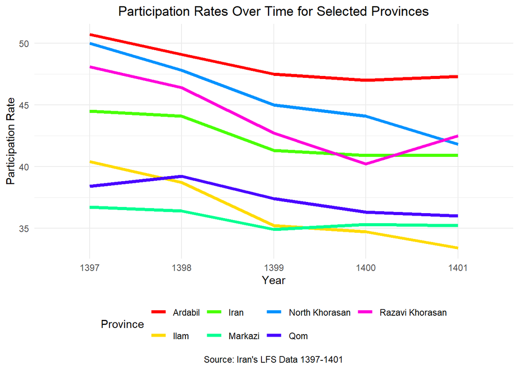

```r
# Plot participation rates over time for selected provinces
ggplot(melted_data, aes(x = variable, y = value, color = Province, group = Province)) +
  geom_line(size = 1.5) +
  labs(x = "Year", y = "Participation Rate",
       title = "Participation Rates Over Time for Selected Provinces",
               caption = "Source: Iran's LFS Data 1397-1401") +
  theme_minimal() +
  theme(legend.position = "bottom",
                plot.title = element_text(hjust = 0.5),      # Center-align the title
        plot.caption = element_text(hjust = 0.5)) +          # Center-align the caption)
  scale_color_manual(values = rainbow(length(unique(melted_data$Province))))
```

### Remove Useless Datasets:

In this part, we will remove datasets which are no longer needed.

```r
# Remove useless datasets
rm(participation_rates_LFS1397, participation_rates_LFS1398, participation_rates_LFS1399, participation_rates_LFS1400, participation_rates_LFS1401, filtered_merged_participation)
```

# 2. Gender-Specific Participation Rates.

## Calculate the male and female participation rates in the provinces with the highest and lowest rates, and compare them with the national rates for the year 1397 and report the results.

### Split the Data by Sex for each year

#### Define `split_data_by_gender`function:

This function splits data into two datasets by `Sex` column.

```r
split_data_by_gender <- function(dataset) {
  # Split dataset into male and female subsets
  male_data <- dataset[dataset$Sex == 1, ]
  female_data <- dataset[dataset$Sex == 2, ]

  return(list(male_data = male_data, female_data = female_data))
}
```

#### Apply the Function:

Now we will apply the function on each year and assign them to the correspondant variable.

```r
# Apply the function and assign male and female data separately for each year
female_data_1397 <- split_data_by_gender(LFS1397_above15_province)$female_data
male_data_1397 <- split_data_by_gender(LFS1397_above15_province)$male_data

female_data_1398 <- split_data_by_gender(LFS1398_above15_province)$female_data
male_data_1398 <- split_data_by_gender(LFS1398_above15_province)$male_data

female_data_1399 <- split_data_by_gender(LFS1399_above15_province)$female_data
male_data_1399 <- split_data_by_gender(LFS1399_above15_province)$male_data

female_data_1400 <- split_data_by_gender(LFS1400_above15_province)$female_data
male_data_1400 <- split_data_by_gender(LFS1400_above15_province)$male_data

female_data_1401 <- split_data_by_gender(LFS1401_above15_province)$female_data
male_data_1401 <- split_data_by_gender(LFS1401_above15_province)$male_data
```

### Calculate the participation Rates:

- Participation rates are calculated for each gender using the `calculate_participation_rates` function.

```r
female_participation_1397 <- calculate_participation_rates(female_data_1397)
female_participation_1398 <- calculate_participation_rates(female_data_1398)
female_participation_1399 <- calculate_participation_rates(female_data_1399)
female_participation_1400 <- calculate_participation_rates(female_data_1400)
female_participation_1401 <- calculate_participation_rates(female_data_1401)

male_participation_1397 <- calculate_participation_rates(male_data_1397)
male_participation_1398 <- calculate_participation_rates(male_data_1398)
male_participation_1399 <- calculate_participation_rates(male_data_1399)
male_participation_1400 <- calculate_participation_rates(male_data_1400)
male_participation_1401 <- calculate_participation_rates(male_data_1401)
```

### Sorting and Printing Top and Bottom Rows:

In this part, we will sort separated data frames by particiaption rates and print the top and bottom rows for males and females separately for the year 1397.

#### Sorting:

- Lists `male_participation_list` and `female_participation_list` are initialized.

```r
# List of male and female participation dataframes for different years
male_participation_list <- list(male_participation_1397, male_participation_1398, male_participation_1399, male_participation_1400, male_participation_1401)
female_participation_list <- list(female_participation_1397, female_participation_1398, female_participation_1399, female_participation_1400, female_participation_1401)
```

- The following loop iterates over each year’s male and female participation datasets.
- For each iteration, it sorts the male and female participation dataframes by descending order of the `Participation_Rate` column.
- It renames the `Province` column using the province dictionary to replace province codes with their names.
- The`Year` column is updated to show the corresponding year of the dataset.
- The `Participation_Rate` column is multiplied by 100 and rounded to one decimal place to represent the rate as a percentage. The column is renamed to `Participation`
- Finally, the sorted, renamed, and updated datasets are assigned back to their original variables.

```r
# Loop through each year to sort and rename male and female participation data
for (i in 1:length(male_participation_list)) {

  # Sort male participation data for the current year and rename province column
  male_participation_list[[i]] <- male_participation_list[[i]] %>%
    arrange(desc(Participation_Rate)) %>%
    mutate(Province = province_dict[as.character(Province)]) %>%
    mutate(Year = 1397 + i - 1) %>%
    mutate(Participation_Rate = round(Participation_Rate * 100, 1)) %>%
    rename(Participation = Participation_Rate)  # Rename Participation_Rate column

  # Sort female participation data for the current year and rename province column
  female_participation_list[[i]] <- female_participation_list[[i]] %>%
    arrange(desc(Participation_Rate)) %>%
    mutate(Province = province_dict[as.character(Province)]) %>%
    mutate(Year = 1397 + i - 1) %>%
    mutate(Participation_Rate = round(Participation_Rate * 100, 1)) %>%
    rename(Participation = Participation_Rate)  # Rename Participation_Rate column

  # Assign sorted data back to original variables
  assign(paste0("male_participation_", 1397 + i - 1), male_participation_list[[i]])
  assign(paste0("female_participation_", 1397 + i - 1), female_participation_list[[i]])
}
```

#### Printing:

The top row (highest participation rate) and bottom row (lowest participation rate) for males and females are printed for the year 1397.

```r
# Print top row for males in 1397
knitr::kable(head(male_participation_1397, 1), align = "lcc", caption = "Top Province for Males 1397", row.names = FALSE)
```

Top Province for Males 1397

| Year | Province | Participation |
| --- | --- | --- |
| 1397 | Kurdistan | 78.8 |

```r
# Print bottom row for males in 1397
knitr::kable(tail(male_participation_1397, 1), align = "lcc", caption = "Bottom Province for Males 1397", row.names = FALSE)
```

Bottom Province for Males 1397

| Year | Province | Participation |
| --- | --- | --- |
| 1397 | Sistan and Baluchestan | 61 |

```r
knitr::kable(head(female_participation_1397, 1), align = "lcc", caption = "Top Province for Females 1397", row.names = FALSE)
```

Top Province for Females 1397

| Year | Province | Participation |
| --- | --- | --- |
| 1397 | North Khorasan | 26.3 |

```r
knitr::kable(tail(female_participation_1397, 1), align = "lcc", caption = "Bottom Province for Females 1397", row.names = FALSE)
```

Bottom Province for Females 1397

| Year | Province | Participation |
| --- | --- | --- |
| 1397 | Markazi | 6.5 |

disparities.

### Calculate and Plot for Males

#### Data Preparation:

- **Dataframe Collection**: Created a list (‘male_participation_list’) containing male participation dataframes for each year (1397 to 1401).

```r
# Define a list to store male participation dataframes for each year
male_participation_list <- list(male_participation_1397, male_participation_1398, male_participation_1399, male_participation_1400, male_participation_1401)
```

- **Conversion and Sorting**: Converted and sorted dataframes based on Province name alphabetically.

```r
# Convert all dataframes to data frame format and sort based on Province name alphabetically
for (i in seq_along(male_participation_list)) {
  # Convert the dataframe to a data frame format
  male_participation_list[[i]] <- as.data.frame(lapply(male_participation_list[[i]], unlist))
  # Sort the dataframe based on Province name alphabetically
  male_participation_list[[i]] <- male_participation_list[[i]][order(male_participation_list[[i]]$Province), ]
}
```

```r
# Rename participation rate columns in each dataframe
for (i in seq_along(male_participation_list)) {
  # Rename the participation rate column to include the corresponding year
  names(male_participation_list[[i]])[names(male_participation_list[[i]]) == "Participation"] <- paste0("Participation_", 1397 + i)
}
```

- **Merging Dataframes**: Combined participation columns into a single dataframe (`male_merged_participation`).

```r
# Merge participation columns from old dataframes based on provinces
male_merged_participation <- male_participation_list[[1]]
for (i in 2:length(male_participation_list)) {
  # Merge the participation columns with the merged dataframe based on Province
  male_merged_participation <- merge(male_merged_participation, male_participation_list[[i]][, -1], by = "Province", all = TRUE)
}
```

- **Provincial Filtering**: Selected specific provinces(Top, Bottom, and National average).

```r
# Filter provinces Iran, Kurdistan, Sistan and Baluchestan
male_filtered_participation <- subset(male_merged_participation, Province %in% c("Iran", "Kurdistan", "Sistan and Baluchestan"))
```

- **Column Dropping**: Removed the `Year` column for consistency.

```r
# Drop the 'Year' column from the dataframe
male_filtered_participation <- subset(male_filtered_participation, select = -Year)
```

- **Printing the Result**: Finally, We will Print the resulted dataframe.

```r
# Print the filtered dataframe
knitr::kable(male_filtered_participation, align = "lcccccc", caption = "Top, Bottom, and National Average of Male Participation Rates Over Time", row.names = FALSE)
```

Top, Bottom, and National Average of Male Participation Rates Over Time

| Province | Participation_1398 | Participation_1399 | Participation_1400 | Participation_1401 | Participation_1402 |
| --- | --- | --- | --- | --- | --- |
| Iran | 71.6 | 71.1 | 68.7 | 68.7 | 68.2 |
| Kurdistan | 78.8 | 76.9 | 75.4 | 74.5 | 74.7 |
| Sistan and Baluchestan | 61.0 | 58.3 | 54.2 | 53.7 | 53.2 |

#### Data Visualization:

- **Dataframe Melting**: Transformed the dataframe into long format suitable for plotting.

```r
# Melt the dataframe to long format for plotting
melted_data <- reshape2::melt(male_filtered_participation, id.vars = "Province")
```

- **Plotting**: Generated a line plot illustrating participation rates over time for selected provinces, with distinct colors for each province.

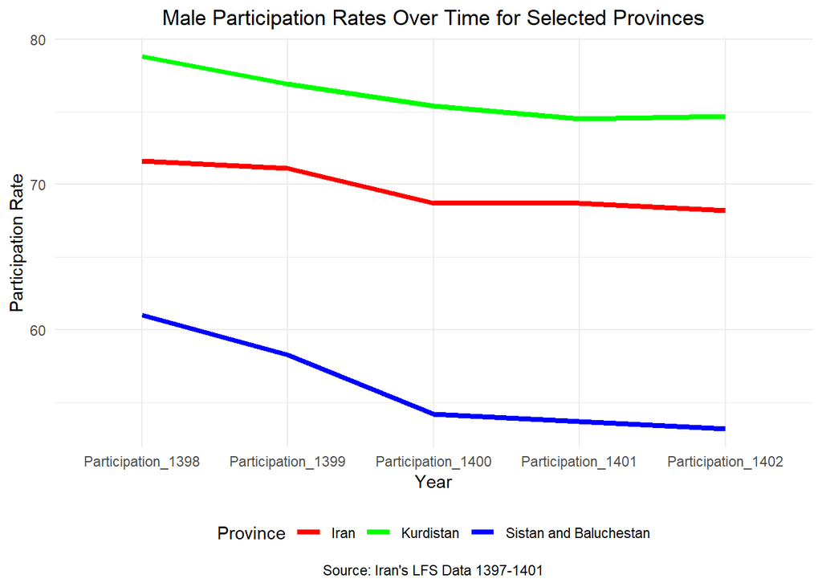

```r
# Plot participation rates over time for selected provinces
ggplot(melted_data, aes(x = variable, y = value, color = Province, group = Province)) +
  geom_line(size = 1.5) +
  labs(x = "Year", y = "Participation Rate",
       title = "Male Participation Rates Over Time for Selected Provinces",
        caption = "Source: Iran's LFS Data 1397-1401") +
  theme_minimal() +
   theme(legend.position = "bottom",
        plot.title = element_text(hjust = 0.5),      # Center-align the title
        plot.caption = element_text(hjust = 0.5)) +  # Center-align the caption
  scale_color_manual(values = rainbow(length(unique(melted_data$Province))))
```

### Calculate and Plot for Females

#### Data Preparation:

- **Dataframe Collection**: Created a list (‘female_participation_list’) containing female participation dataframes for each year (1397 to 1401).

```r
# Define a list to store female participation dataframes for each year
female_participation_list <- list(female_participation_1397, female_participation_1398, female_participation_1399, female_participation_1400, female_participation_1401)
```

- **Conversion and Sorting**: Converted and sorted dataframes based on Province name alphabetically.

```r
# Convert all dataframes to data frame format and sort based on Province name alphabetically
for (i in seq_along(female_participation_list)) {
  female_participation_list[[i]] <- as.data.frame(lapply(female_participation_list[[i]], unlist))
  female_participation_list[[i]] <- female_participation_list[[i]][order(female_participation_list[[i]]$Province), ]
}
```

```r
# Rename participation rate columns in each dataframe
for (i in seq_along(female_participation_list)) {
  # Rename the participation rate column to include the corresponding year
  names(female_participation_list[[i]])[names(female_participation_list[[i]]) == "Participation"] <- paste0("Participation_", 1397 + i)
}
```

- **Merging Dataframes**: Combined participation columns into a single dataframe (`female_merged_participation`).

```r
# Merge participation columns from old dataframes based on provinces
female_merged_participation <- female_participation_list[[1]]
for (i in 2:length(female_participation_list)) {
  # Merge the participation columns with the merged dataframe based on Province
  female_merged_participation <- merge(female_merged_participation, female_participation_list[[i]][, -1], by = "Province", all = TRUE)
}
```

- **Provincial Filtering**: Selected specific provinces(Top, Bottom, and National average).

```r
# Filter provinces Iran, North Khorasan, Markazi
female_filtered_participation <- subset(female_merged_participation, Province %in% c("Iran", "North Khorasan", "Markazi"))
```

- **Column Dropping**: Removed the `Year` column for consistency.

```r
# Drop the 'Year' column from the dataframe
female_filtered_participation <- subset(female_filtered_participation, select = -Year)
```

- **Printing the Result**: Finally, We will Print the resulted dataframe.

```r
# Print the filtered dataframe
knitr::kable(female_filtered_participation, align = "lcccccc", caption = "Top, Bottom. and National Average of Female Participation Rates Over Time", row.names = FALSE)
```

Top, Bottom. and National Average of Female Participation Rates Over Time

| Province | Participation_1398 | Participation_1399 | Participation_1400 | Participation_1401 | Participation_1402 |
| --- | --- | --- | --- | --- | --- |
| Iran | 17.6 | 17.0 | 13.9 | 13.3 | 13.6 |
| Markazi | 6.5 | 5.9 | 5.9 | 6.4 | 6.1 |
| North Khorasan | 26.3 | 24.0 | 21.3 | 20.0 | 16.7 |

#### Data Visualization:

- **Dataframe Melting**: Transformed the dataframe into long format suitable for plotting.

```r
# Melt the dataframe to long format for plotting
melted_data <- reshape2::melt(female_filtered_participation, id.vars = "Province")
```

- **Plotting**: Generate a line plot showing participation rates over time for selected provinces, with distinct colors for each province.

[figure not shown]

```r
# Plot participation rates over time for selected provinces
ggplot(melted_data, aes(x = variable, y = value, color = Province, group = Province)) +
  geom_line(size = 1.5) +
  labs(x = "Year", y = "Participation Rate",
       title = "Male Participation Rates Over Time for Selected Provinces",
       caption = "Source: Iran's LFS Data 1397-1401") +  # Adding caption with source
  theme_minimal() +
  theme(legend.position = "bottom",
        plot.title = element_text(hjust = 0.5),  # Center-align the title
        plot.caption = element_text(hjust = 0.5)) +  # Center-align the caption
  scale_color_manual(values = rainbow(length(unique(melted_data$Province))))
```

### Remove Useless Datasets:

In this part, we will remove datasets which are no longer needed.

```r
# Remove useless datasets
rm(male_participation_list, female_participation_list, male_filtered_participation, male_participation_1397, male_participation_1398, male_participation_1399, male_participation_1400, male_participation_1401, female_filtered_participation, female_participation_1397, female_participation_1398, female_participation_1399, female_participation_1400, female_participation_1401, male_merged_participation, female_merged_participation, participation_rates, participation_rates_sorted, LFS1397_above15_province, LFS1398_above15_province, LFS1399_above15_province, LFS1400_above15_province, LFS1401_above15_province)
```

# 3. Sectoral Employment and Work Hours.

## Determine the female and male share in the three sectors asked in LFS.

### Clean and Process Employment Role

#### Define Dictionary for Employment Roles

In this section, a dictionary named `employment_role_dict` is defined which maps numeric codes representing employment roles to their corresponding descriptive labels.

```r
# Define the dictionary
employment_role_dict <- c("01" = "Employers",
                          "02" = "Independent and Family Workers",
                          "03" = "Independent and Family Workers",
                          "04" = "Wage and Salary Earners",
                          "05" = "Wage and Salary Earners",
                          "06" = "Wage and Salary Earners",
                          "07" = "Interns",
                          "08" = "Interns",
                          "09" = "Interns",
                          "10" = "Interns")
```

#### Clean Employment Role Data for Male and Female Datasets

In the following block, I have written a for loop which does this steps:

- **Looping Through Years**: We iterate over each year from 1397 to 1401 using a for loop.
- **Dataset Retrieval**: For each year, we retrieve the male and female datasets using `get()` function.
- **Data Cleaning for Males**: We drop null values from the “Employment Role” column and replace the values using the dictionary for males.
- **Data Cleaning for Females**: Similarly, we drop null values from the “Employment Role” column and replace the values using the dictionary for females.
- **Assigning Modified Datasets**: We assign the processed datasets to new dataframes.

```r
# Clean and Process Employment Role Data for Males and Females
# Loop through each year
for (year in c(1397, 1398, 1399, 1400, 1401)) {
  # Get male and female datasets for the current year
  male_data_year <- get(paste0("male_data_", year))
  female_data_year <- get(paste0("female_data_", year))

  # Drop rows with null values and replace values using the dictionary for males
  male_Role_Processed <- male_data_year
  male_Role_Processed$`Employment Role` <- employment_role_dict[as.character(male_Role_Processed$`Employment Role`)]
  male_Role_Processed <- male_Role_Processed[!is.na(male_Role_Processed$`Employment Role`), ]


  # Drop rows with null values and replace values using the dictionary for females
  female_Role_Processed <- female_data_year
  female_Role_Processed$`Employment Role` <- employment_role_dict[as.character(female_Role_Processed$`Employment Role`)]
  female_Role_Processed <- female_Role_Processed[!is.na(female_Role_Processed$`Employment Role`), ]

  # Assign the modified datasets to new dataframes with appropriate names
  assign(paste0("male_Role_Processed_", year), male_Role_Processed)
  assign(paste0("female_Role_Processed_", year), female_Role_Processed)
}
```

### **Remove Useless Datasets:**

In this part, we will remove datasets which are no longer needed.

```r
# Remove useless datasets
rm(male_Role_Processed, female_Role_Processed, male_data_year, female_data_year)
```

### Determining Male and Female Share in Each Sector

In the following block, I have written a for loop which does the following steps:

- **Iteration Over Years**: The outer loop iterates over each year from 1397 to 1401.
- **Iteration Over Employment Roles**: The inner loop iterates over each unique employment role category.
- **Data Retrieval**: For each year and employment role, the processed male and female datasets are retrieved.
- **Calculation of Sums**: The sums of weights for males and females for the current employment role category and year are calculated.
- **Calculation of Shares**: The share of each gender for the current employment role category is calculated as a percentage, rounded to 2 decimal places.
- **Storage of Results**:
  - The results are stored in a list for each year.
  - Each element of the list contains a dataframe with sector-gender shares for that year.
- **Assignment to Unique Dataframe**: The results for each year are assigned to unique dataframe variables using the `assign()` function.
- **Displaying the Results**: For each year, the results are displayed using the specified style with the `knitr::kable()` function.

```r
# Initialize an empty list to store the results
sector_gender_share_list <- list()

# Iterate over each year
for (year in c(1397, 1398, 1399, 1400, 1401)) {

  # Initialize a list to store the results for the current year
  year_results <- list()

  # Iterate over each employment role category
  for (role in unique(employment_role_dict)) {

    # Get processed male and female datasets for the current year and role
    male_data_year <- get(paste0("male_Role_Processed_", year))
    female_data_year <- get(paste0("female_Role_Processed_", year))

    # Calculate the sum of weights for males and females for the current role and year
    sum_male <- sum(male_data_year$Weight[male_data_year$`Employment Role` == role])
    sum_female <- sum(female_data_year$Weight[female_data_year$`Employment Role` == role])

    # Calculate the total sum of weights for both genders
    total_sum <- sum_male + sum_female

    # Calculate the share of each gender for the current employment role category
    share_male <- round(sum_male / total_sum * 100, 2)
    share_female <- round(sum_female / total_sum * 100, 2)

    # Store the results in a data frame
    year_results[[role]] <- data.frame(Sector = role,
                                       Male_Share = share_male,
                                       Female_Share = share_female)
  }

  # Combine all sector-gender shares for the current year into one data frame
  year_results_df <- do.call(rbind, year_results)

  # Assign the results for the current year to a unique dataframe variable
  assign(paste0("sector_gender_share_", year), year_results_df)

  # Append the results for the current year to the list
  sector_gender_share_list[[year]] <- year_results_df

  # Show the results for the current year
  print(knitr::kable(year_results_df, align = "lcc", caption = paste("Share of Gender in Each Sector at", year), row.names = FALSE), "\n\n")
}
```

```
##
##
## Table: Share of Gender in Each Sector at 1397
##
## |Sector                         | Male_Share | Female_Share |
## |:------------------------------|:----------:|:------------:|
## |Employers                      |   93.92    |     6.08     |
## |Independent and Family Workers |   81.66    |    18.34     |
## |Wage and Salary Earners        |   81.18    |    18.82     |
## |Interns                        |   58.99    |    41.01     |
##
##
## Table: Share of Gender in Each Sector at 1398
##
## |Sector                         | Male_Share | Female_Share |
## |:------------------------------|:----------:|:------------:|
## |Employers                      |   94.51    |     5.49     |
## |Independent and Family Workers |   82.04    |    17.96     |
## |Wage and Salary Earners        |   81.67    |    18.33     |
## |Interns                        |   56.72    |    43.28     |
##
##
## Table: Share of Gender in Each Sector at 1399
##
## |Sector                         | Male_Share | Female_Share |
## |:------------------------------|:----------:|:------------:|
## |Employers                      |   95.35    |     4.65     |
## |Independent and Family Workers |   84.74    |    15.26     |
## |Wage and Salary Earners        |   83.39    |    16.61     |
## |Interns                        |   68.00    |    32.00     |
##
##
## Table: Share of Gender in Each Sector at 1400
##
## |Sector                         | Male_Share | Female_Share |
## |:------------------------------|:----------:|:------------:|
## |Employers                      |   95.57    |     4.43     |
## |Independent and Family Workers |   85.51    |    14.49     |
## |Wage and Salary Earners        |   84.15    |    15.85     |
## |Interns                        |   66.13    |    33.87     |
##
##
## Table: Share of Gender in Each Sector at 1401
##
## |Sector                         | Male_Share | Female_Share |
## |:------------------------------|:----------:|:------------:|
## |Employers                      |   94.19    |     5.81     |
## |Independent and Family Workers |   85.93    |    14.07     |
## |Wage and Salary Earners        |   83.21    |    16.79     |
## |Interns                        |   62.95    |    37.05     |
```

## Find the average hours worked by each gender in these sectors.

In the following block, I have written a for loop which does the following steps: * **Iteration Over Years**: The outer loop iterates over each year from 1397 to 1401.

- **Iteration Over Employment Roles**: The inner loop iterates over each unique employment role category.
- **Data Retrieval**: For each year and employment role, the processed male and female datasets are retrieved.
- **Conversion of “Work H/Week” to Numeric**: The “Work H/Week” column is converted to numeric using `as.numeric()` function.
- **Calculation of Weighted Average Hours**: The weighted average hours worked per week for males and females within each sector are calculated using the `weighted.mean()` function, with the “Weight” column used as weights.
- **Storage of Results**:
  - The results are stored in a list for each year.
  - Each element of the list contains a dataframe with sector-gender average hours worked for that year.
- **Assignment to Unique Dataframe**: The results for each year are assigned to unique dataframe variables using the `assign()` function.
- **Displaying the Results**: For each year, the results are displayed using the specified style with the `knitr::kable()` function.

```r
# Initialize an empty list to store the results
avg_hours_worked_list <- list()

# Create an empty list to store the average hours worked for each gender
avg_hours_list <- list()

# Iterate over each year
for (year in c(1397, 1398, 1399, 1400, 1401)) {

  # Initialize a list to store the results for the current year
  year_results <- list()

  # Iterate over each employment role category
  for (role in unique(employment_role_dict)) {

    # Get processed male and female datasets for the current year and role
    male_data_year <- get(paste0("male_Role_Processed_", year))
    female_data_year <- get(paste0("female_Role_Processed_", year))

    # Convert "Work H/Week" column to numeric
    male_data_year$`Work H/Week` <- as.numeric(male_data_year$`Work H/Week`)
    female_data_year$`Work H/Week` <- as.numeric(female_data_year$`Work H/Week`)

    # Calculate the weighted average hours worked per week for males and females for the current role and year
    avg_hours_male <- round(weighted.mean(male_data_year$`Work H/Week`[male_data_year$`Employment Role` == role],
                                          w = male_data_year$Weight[male_data_year$`Employment Role` == role], na.rm = TRUE), 2)
    avg_hours_female <- round(weighted.mean(female_data_year$`Work H/Week`[female_data_year$`Employment Role` == role],
                                            w = female_data_year$Weight[female_data_year$`Employment Role` == role], na.rm = TRUE), 2)

    # Store the results in a data frame
    year_results[[role]] <- data.frame(Sector = role,
                                       Avg_Hours_Male = avg_hours_male,
                                       Avg_Hours_Female = avg_hours_female)
  }

  # Combine all sector-gender average hours for the current year into one data frame
  year_results_df <- do.call(rbind, year_results)

  # Assign the results for the current year to a unique dataframe variable
  assign(paste0("avg_hours_worked_", year), year_results_df)

  # Append the results for the current year to the list
  avg_hours_worked_list[[year]] <- year_results_df

    # Store the average hours worked for the current year
  avg_hours_list[[year]] <- data.frame(Year = year, Gender = c("Male", "Female"), Average_Hours = c(avg_hours_male, avg_hours_female))

  # Show the results for the current year
  print(knitr::kable(year_results_df, align = "lcc", caption = paste("Share of Gender in Each Sector at", year), row.names = FALSE))
}
```

```
##
##
## Table: Share of Gender in Each Sector at 1397
##
## |Sector                         | Avg_Hours_Male | Avg_Hours_Female |
## |:------------------------------|:--------------:|:----------------:|
## |Employers                      |     52.38      |      40.58       |
## |Independent and Family Workers |     47.77      |      27.84       |
## |Wage and Salary Earners        |     49.90      |      38.92       |
## |Interns                        |     45.05      |      33.19       |
##
##
## Table: Share of Gender in Each Sector at 1398
##
## |Sector                         | Avg_Hours_Male | Avg_Hours_Female |
## |:------------------------------|:--------------:|:----------------:|
## |Employers                      |     52.14      |      40.70       |
## |Independent and Family Workers |     47.40      |      27.86       |
## |Wage and Salary Earners        |     49.77      |      38.24       |
## |Interns                        |     44.45      |      30.06       |
##
##
## Table: Share of Gender in Each Sector at 1399
##
## |Sector                         | Avg_Hours_Male | Avg_Hours_Female |
## |:------------------------------|:--------------:|:----------------:|
## |Employers                      |     49.71      |      34.89       |
## |Independent and Family Workers |     46.46      |      27.96       |
## |Wage and Salary Earners        |     48.10      |      38.04       |
## |Interns                        |     46.90      |      36.09       |
##
##
## Table: Share of Gender in Each Sector at 1400
##
## |Sector                         | Avg_Hours_Male | Avg_Hours_Female |
## |:------------------------------|:--------------:|:----------------:|
## |Employers                      |     50.65      |      42.13       |
## |Independent and Family Workers |     47.28      |      29.34       |
## |Wage and Salary Earners        |     48.34      |      39.45       |
## |Interns                        |     45.83      |      32.81       |
##
##
## Table: Share of Gender in Each Sector at 1401
##
## |Sector                         | Avg_Hours_Male | Avg_Hours_Female |
## |:------------------------------|:--------------:|:----------------:|
## |Employers                      |     50.27      |      43.20       |
## |Independent and Family Workers |     47.99      |      30.59       |
## |Wage and Salary Earners        |     48.95      |      39.83       |
## |Interns                        |     45.39      |      34.86       |
```

## Plot the average hours worked alongside the gender share for each sector from 1397 to 1401.

### Average Hours Worked

#### **Dataset Merging and Transformation**:

- **Dataset Retrieval**: Iterate over each dataset from 1397 to 1401.
- **Year Extraction**: Extract the year from the dataset name.
- **Melt Operation**: Convert the dataset from wide to long format using `melt()` function from the `reshape2` package.
- **Binary Variable Creation**: Create a binary variable indicating male or female based on the variable names.
- **Column Renaming**: Modify the variable names to remove “_Male” or “_Female”.
- **Year Column Addition**: Add a column indicating the year of the dataset.
- **List Appending**: Append the transformed dataset to a list.
- **Merging Datasets**: Use `do.call()` with `rbind()` to merge all datasets into one.

```r
# List of dataset names
dataset_names <- c("avg_hours_worked_1397", "avg_hours_worked_1398", "avg_hours_worked_1399", "avg_hours_worked_1400", "avg_hours_worked_1401")

# Initialize an empty list to store the merged datasets
merged_datasets <- list()

# Iterate over each dataset
for (name in dataset_names) {
  # Extract the year from the dataset name
  year <- substr(name, nchar(name) - 3, nchar(name))

  # Get the dataset
  df <- get(name)

  # Melt the dataset to long format
  melted_df <- reshape2::melt(df, id.vars = "Sector")

  # Create a binary variable for male and female
  melted_df$Sex <- ifelse(grepl("Male", melted_df$variable), "Male", "Female")

  # Remove "Male" or "Female" from the variable names
  melted_df$variable <- gsub("_Male|_Female", "", melted_df$variable)

  # Add a column for the year
  melted_df$Year <- as.numeric(year)

  # Append the dataset to the list of merged datasets
  merged_datasets[[year]] <- melted_df
}

# Merge all datasets into one
avg_hours_merged <- do.call(rbind, merged_datasets)
```

#### **Plotting the Trend**:

The graph shows different colors for males and females, with each sector displayed in separate panels for clarity. The title and caption are centered, and a simple theme is applied to the graph. The legend is placed at the bottom to enhance visualization.

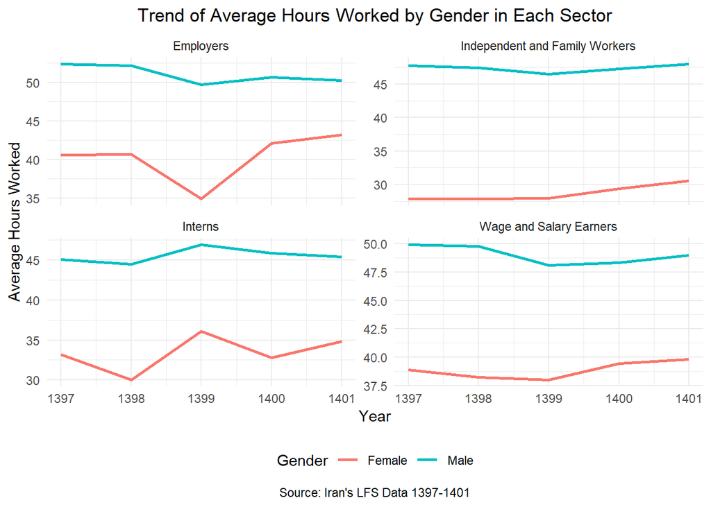

```r
# Plot the trend for each sector with center-aligned title and caption
ggplot(avg_hours_merged, aes(x = Year, y = value, color = Sex)) +
  geom_line(size = 1) +
  facet_wrap(~ Sector, scales = "free_y") +
  labs(title = "Trend of Average Hours Worked by Gender in Each Sector",
       x = "Year",
       y = "Average Hours Worked",
       color = "Gender",
       caption = "Source: Iran's LFS Data 1397-1401") +
  theme_minimal() +
  theme(legend.position = "bottom",
        plot.title = element_text(hjust = 0.5),      # Center-align the title
        plot.caption = element_text(hjust = 0.5))    # Center-align the caption
```

### Sector Gender Share

#### **Data Preprocessing:**

- First, we rename columns in each dataframe representing gender shares for the years 1397 to 1401. We assign new names “Male” and “Female” to the columns originally named “Male_Share” and “Female_Share” in each dataset.
- Next, we initialize an empty list to store the merged datasets. We iterate over each dataset to extract the year from its name, melt the dataset to long format, rename columns for clarity, add a column for the year, and append the dataset to the list of merged datasets.

```r
# Rename columns in each dataframe
for (i in 1397:1401) {
  assign(paste0("sector_gender_share_", i), get(paste0("sector_gender_share_", i)) %>%
           rename(Male = Male_Share, Female = Female_Share))
}


# List of dataset names
dataset_names <- c("sector_gender_share_1397", "sector_gender_share_1398", "sector_gender_share_1399", "sector_gender_share_1400", "sector_gender_share_1401")

# Initialize an empty list to store the merged datasets
merged_datasets <- list()

# Iterate over each dataset
for (name in dataset_names) {
  # Extract the year from the dataset name
  year <- as.numeric(str_extract(name, "[0-9]+"))

  # Get the dataset
  df <- get(name)

  # Melt the dataset to long format
  melted_df <- reshape2::melt(df, id.vars = "Sector")

  # Rename columns for clarity
  colnames(melted_df) <- c("Sector", "Gender", "Share")

  # Add a column for the year
  melted_df$Year <- year

  # Append the dataset to the list of merged datasets
  merged_datasets[[year]] <- melted_df
}
```

#### **Data Merging:**

- After merging all datasets into one using `do.call(rbind, merged_datasets)`, we reverse the order of levels for the “Gender” variable, ensuring “Female” is plotted before “Male” in the legend and colors.

```r
# Merge all datasets into one
gender_share_merged <- do.call(rbind, merged_datasets)

# Reverse the order of levels for the "Gender" variable
gender_share_merged <- gender_share_merged %>%
  mutate(Gender = factor(Gender, levels = c("Female", "Male")))
```

#### **Plotting the Trend**:

- Finally, we plot the trend for each sector, facet-wrapped by sector, with center-aligned title and caption. We use ggplot2 for visualization and set aesthetics for the x-axis, y-axis, color (representing gender), title, and caption. The plot is themed with minimal design, and both the title and caption are center-aligned.

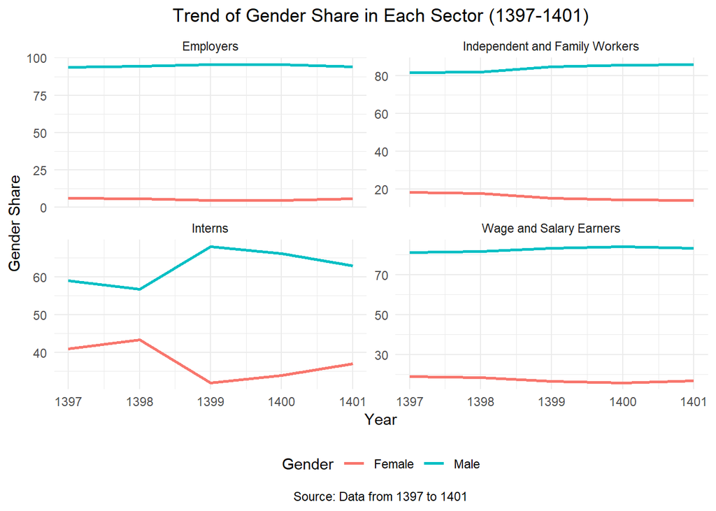

```r
# Plot the trend for each sector with center-aligned title and caption
ggplot(gender_share_merged, aes(x = Year, y = Share, color = Gender)) +
  geom_line(size = 1) +
  facet_wrap(~ Sector, scales = "free_y") +
  labs(title = "Trend of Gender Share in Each Sector (1397-1401)",
       x = "Year",
       y = "Gender Share",
       color = "Gender",
       caption = "Source: Data from 1397 to 1401") +
  theme_minimal() +
  theme(legend.position = "bottom",
        plot.title = element_text(hjust = 0.5),      # Center-align the title
        plot.caption = element_text(hjust = 0.5))    # Center-align the caption
```

### Remove Useless Datasets:

In this part, we will remove datasets which are no longer needed.

```r
# Remove useless datasets
rm(male_data_1397, male_data_1398, male_data_1399, male_data_1401, female_data_1397, female_data_1398, female_data_1399, female_data_1401, female_Role_Processed_1397, female_Role_Processed_1398, female_Role_Processed_1399, female_Role_Processed_1400, female_Role_Processed_1401, male_Role_Processed_1397, male_Role_Processed_1398, male_Role_Processed_1399, male_Role_Processed_1400, male_Role_Processed_1401)
```

# 4. Reasons for Job Leave.

the year 1400 and plot the results.

### Define the Dictionary:

- A dictionary (`job_leave_dict`) is defined with codes as keys and corresponding job leave reasons as values.

```r
# Define the dictionary
job_leave_dict <- c("01" = "Low Income",
                    "02" = "Permanent Workplace Closure",
                    "03" = "Seasonal Employment",
                    "04" = "Temporary Employment",
                    "05" = "Job Relocation",
                    "06" = "Education or Training",
                    "07" = "Layoff",
                    "08" = "Family Issues",
                    "09" = "Migration",
                    "10" = "Retirement",
                    "11" = "Completion of Military Service",
                    "12" = "Elderliness",
                    "13" = "Illness",
                    "14" = "Other")
```

### Updating Job Leave Column and Filtering Datasets (1400)

- **Update Job Leave Column:** Loop through the year 1400, retrieve the male and female datasets for that year, and apply the dictionary to the Job Leave column for both datasets, replacing codes with descriptive reasons. Convert values not found in the dictionary to `NA`.
- **Remove Rows with Null Job Leave Values:** Drop rows with `NA` values in the Job Leave column for both male and female datasets.
- **Assign New Datasets**: Assign the updated datasets to new variables with appropriate names (`male_job_leave_1400` and `female_job_leave_1400`).

```r
# Create new datasets for males and females with updated Job Leave column
for (year in 1400:1400) {
  # Get male and female datasets for the current year
  male_data <- get(paste0("male_data_", year))
  female_data <- get(paste0("female_data_", year))

  # Apply the dictionary to the Job Leave column
  male_data$`Job Leave` <- ifelse(male_data$`Job Leave` %in% names(job_leave_dict), job_leave_dict[male_data$`Job Leave`], NA)
  female_data$`Job Leave` <- ifelse(female_data$`Job Leave` %in% names(job_leave_dict), job_leave_dict[female_data$`Job Leave`], NA)

  # Drop rows with NA values in Job Leave column
  male_data <- male_data[!is.na(male_data$`Job Leave`), ]
  female_data <- female_data[!is.na(female_data$`Job Leave`), ]

  # Assign new datasets with appropriate names
  assign(paste0("male_job_leave_", year), male_data)
  assign(paste0("female_job_leave_", year), female_data)
}
```

### Aggregate Reasons Function

```r
# Function to aggregate reasons with weighted percentages less than 2% into "Other" category
aggregate_reasons <- function(df) {
  # Calculate the total weight
  total_weight <- sum(df$Weight)

  # define threshold
  threshold <- 1.5

  # Calculate the weighted percentage for each reason
  df <- df %>%
    group_by(`Job Leave`) %>%
    summarize(Weighted_Percent = sum(Weight) / total_weight * 100) %>%
    mutate(`Job Leave` = ifelse(Weighted_Percent < threshold, "Other", `Job Leave`)) %>%
    group_by(`Job Leave`) %>%
    summarize(Weighted_Percent = sum(Weighted_Percent)) %>%
    arrange(desc(Weighted_Percent))

  return(df)
}
```

### Aggregate Reasons for Females and Males

- Applies aggregation function to female and male job leave datasets for 1400.
- Results in dataframes of top reasons and an “Other” category.

```r
# Aggregate reasons for female job leave in 1400
female_job_leave_1400_aggregated <- aggregate_reasons(female_job_leave_1400)

# Aggregate reasons for male job leave in 1400
male_job_leave_1400_aggregated <- aggregate_reasons(male_job_leave_1400)
```

### Plotting Pie Charts

- Utilizes ggplot2 to visualize aggregated job leave reasons for females and males in 1400.
- Titles are centered, legends are positioned to the right, and captions provide data source information.

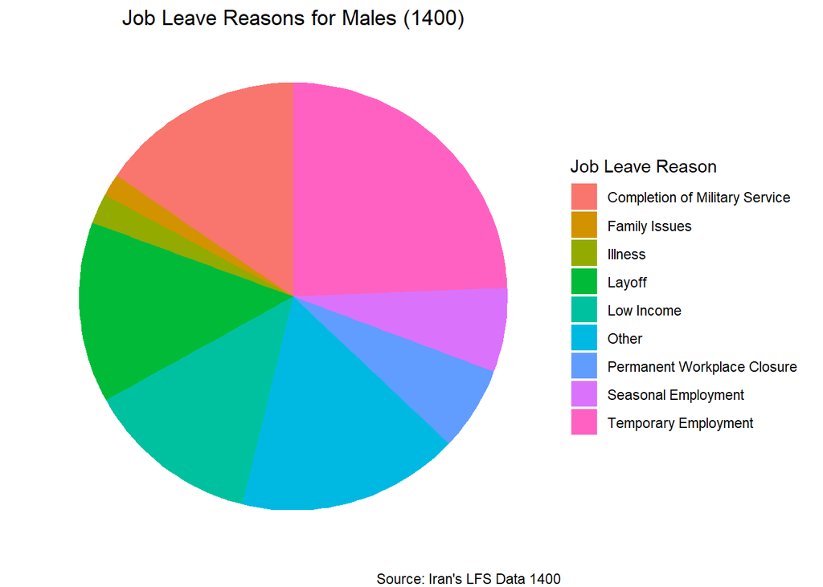

```r
# Plot pie chart for male job leave reasons in 1400
ggplot(male_job_leave_1400_aggregated, aes(x = "", y = Weighted_Percent, fill = `Job Leave`)) +
  geom_bar(stat = "identity", width = 1) +
  coord_polar(theta = "y") +
  labs(title = "Job Leave Reasons for Males (1400)",
       fill = "Job Leave Reason",
       caption = "Source: Iran's LFS Data 1400") +
  theme_void() +
  theme(legend.position = "right",
        plot.title = element_text(hjust = 0.5))  # Center-align the title
```

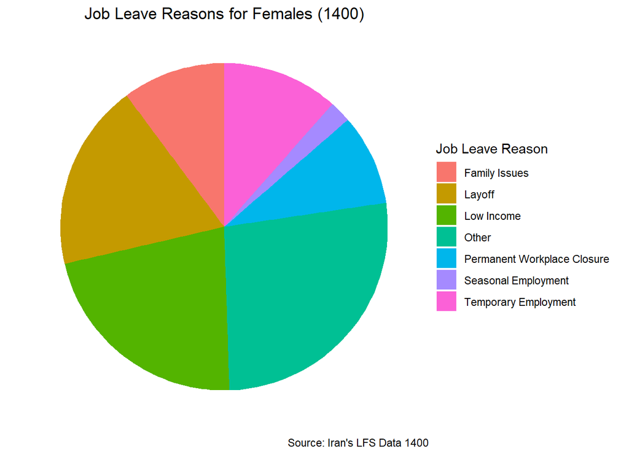

```r
# Plot pie chart for female job leave reasons in 1400
ggplot(female_job_leave_1400_aggregated, aes(x = "", y = Weighted_Percent, fill = `Job Leave`)) +
  geom_bar(stat = "identity", width = 1) +
  coord_polar(theta = "y") +
  labs(title = "Job Leave Reasons for Females (1400)",
       fill = "Job Leave Reason",
       caption = "Source: Iran's LFS Data 1400") +
  theme_void() +
  theme(legend.position = "right",
        plot.title = element_text(hjust = 0.5))  # Center-align the title
```

## Analyze the dataset to extract the top reasons for job leave among single and married females in the year 1400 and plot the results.

### Split the Dataset:

- We updated the values in the “Marriage” column of the `female_job_leave_1400` dataset. Individuals with a value of 1 in the “Marriage” column are assigned the label “Married”, while others are assigned the label “Single”.

```r
# Update values in the "Marriage" column
female_job_leave_1400$Marriage <- ifelse(female_job_leave_1400$Marriage == 1, "Married", "Single")
```

- Then, we split the dataset into two separate datasets based on the “Marriage” column. The `single_females_1400` dataset contains records of females who are single, while the `married_females_1400` dataset contains records of females who are married.
- After that, we aggregate the job leave reasons for each group separately, by calculating the weighted percentage of each job leave reason within each group.

```r
# Split the dataset into two separate datasets based on the "Marriage" column
single_females_1400 <- female_job_leave_1400[female_job_leave_1400$Marriage != "Married", ]
married_females_1400 <- female_job_leave_1400[female_job_leave_1400$Marriage == "Married", ]

# Aggregate job leave reasons for single and married females separately
female_job_leave_1400_single <- aggregate_reasons(single_females_1400)
female_job_leave_1400_married <- aggregate_reasons(married_females_1400)
```

### Plotting Pie Charts:

Finally, we plotted pie charts to visualize the top reasons for job leave among single and married females in 1400.

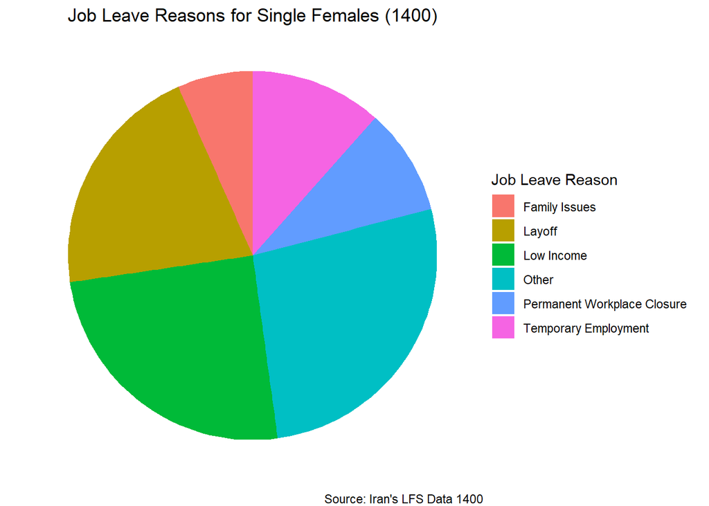

```r
# Plot pie chart for female job leave reasons in 1400
ggplot(female_job_leave_1400_single, aes(x = "", y = Weighted_Percent, fill = `Job Leave`)) +
  geom_bar(stat = "identity", width = 1) +
  coord_polar(theta = "y") +
  labs(title = "Job Leave Reasons for Single Females (1400)",
       fill = "Job Leave Reason",
       caption = "Source: Iran's LFS Data 1400") +
  theme_void() +
  theme(legend.position = "right",
        plot.title = element_text(hjust = 0.5))  # Center-align the title
```

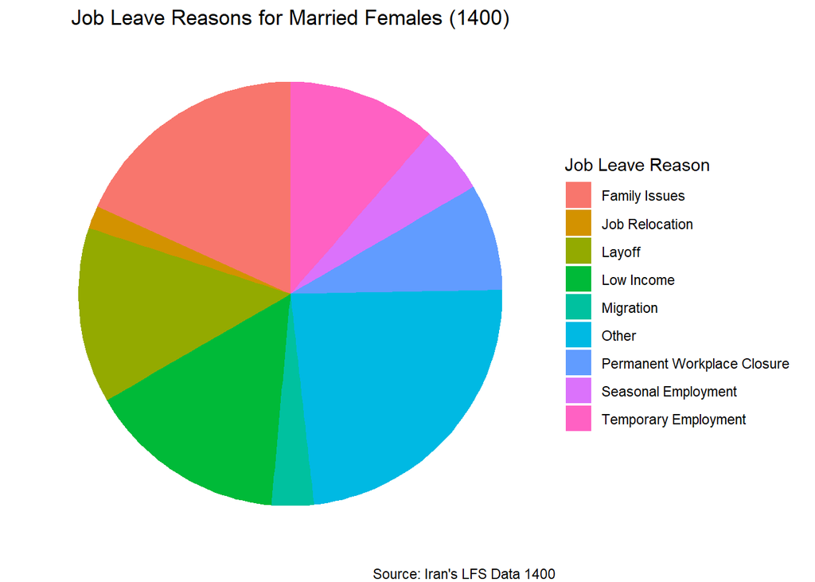

```r
# Plot pie chart for female job leave reasons in 1400
ggplot(female_job_leave_1400_married, aes(x = "", y = Weighted_Percent, fill = `Job Leave`)) +
  geom_bar(stat = "identity", width = 1) +
  coord_polar(theta = "y") +
  labs(title = "Job Leave Reasons for Married Females (1400)",
       fill = "Job Leave Reason",
       caption = "Source: Iran's LFS Data 1400") +
  theme_void() +
  theme(legend.position = "right",
        plot.title = element_text(hjust = 0.5))  # Center-align the title
```

# 5. Gender Gap Analysis.

## Discuss potential reasons for the gender gap in workforce participation between male and female workers.

### **Family Issues**:

**Married women** often leave their jobs due to family issues. However, this factor has less impact on **single women** and even less on **men**.

### **Low Income**:

Women have the choice not to work if they prefer. The chart illustrates that **low income** is a significant reason for women leaving their jobs. In contrast, men often feel compelled to provide for their families and may accept low-paid positions.

Additionally, some of the income disparity may result from **wage discrimination** between men and women.

### **Masculine Workspaces**:

The data shows that **men dominate** the labor force in Iran. Consequently, workspaces may be perceived as **less welcoming** for women.